# Choix des nouveaux taxons à inclure dans les analyses

Author

Aline Davias

Published

December 8, 2023

# Description générale des taxons

## Correspondance taxonomique

Table 1: Correspondance taxonomique

| ch_feces_phylum_ASVbased_Y1 | ch_feces_class_ASVbased_Y1 | ch_feces_order_ASVbased_Y1 | ch_feces_family_ASVbased_Y1 | ch_feces_genus_ASVbased_Y1 |
| --- | --- | --- | --- | --- |
| Actinobacteria | Actinobacteria | Bifidobacteriales | Bifidobacteriaceae | Bifidobacterium |
| Actinobacteria | Actinobacteria | Coriobacteriales | Coriobacteriaceae | Collinsella |
| Actinobacteria | Actinobacteria | Coriobacteriales | Coriobacteriaceae | Eggerthella |
| Actinobacteria | Actinobacteria | Coriobacteriales | Coriobacteriaceae | Senegalimassilia |
| Actinobacteria | Actinobacteria | Coriobacteriales | Coriobacteriaceae | Adlercreutzia |
| Actinobacteria | Actinobacteria | Coriobacteriales | Coriobacteriaceae | Slackia |
| Actinobacteria | Actinobacteria | Coriobacteriales | Coriobacteriaceae | Gordonibacter |
| Actinobacteria | Actinobacteria | Coriobacteriales | Coriobacteriaceae | Olsenella |
| Actinobacteria | Actinobacteria | Coriobacteriales | Coriobacteriaceae | Asaccharobacter |
| Actinobacteria | Actinobacteria | Actinomycetales | Actinomycetaceae | Actinomyces |
| Actinobacteria | Actinobacteria | Coriobacteriales | Coriobacteriaceae | Atopobium |
| Actinobacteria | Actinobacteria | Actinomycetales | Micrococcaceae | Rothia |
| Actinobacteria | Actinobacteria | Bifidobacteriales | Bifidobacteriaceae | Parascardovia |
| Actinobacteria | Actinobacteria | Actinomycetales | Nocardiaceae | Gordonia |
| Actinobacteria | Actinobacteria | Actinomycetales | Corynebacteriaceae | Corynebacterium |
| Actinobacteria | Actinobacteria | Coriobacteriales | Coriobacteriaceae | Cryptobacterium |
| Actinobacteria | Actinobacteria | Actinomycetales | Propionibacteriaceae | Propionibacterium |
| Actinobacteria | Actinobacteria | Actinomycetales | Cellulomonadaceae | Tropheryma |
| Actinobacteria | Actinobacteria | Actinomycetales | Actinomycetaceae | Varibaculum |
| Actinobacteria | Actinobacteria | Coriobacteriales | Coriobacteriaceae | Paraeggerthella |
| Actinobacteria | Actinobacteria | Coriobacteriales | Coriobacteriaceae | Enterorhabdus |
| Actinobacteria | Actinobacteria | Coriobacteriales | Coriobacteriaceae | Parvibacter |
| Actinobacteria | Actinobacteria | Bifidobacteriales | Bifidobacteriaceae | Pseudoscardovia |
| Actinobacteria | Actinobacteria | Bifidobacteriales | Bifidobacteriaceae | Gardnerella |
| Firmicutes | Clostridia | Clostridiales | Lachnospiraceae | Blautia |
| Firmicutes | Clostridia | Clostridiales | Ruminococcaceae | Faecalibacterium |
| Firmicutes | Bacilli | Lactobacillales | Streptococcaceae | Streptococcus |
| Firmicutes | Clostridia | Clostridiales | Lachnospiraceae | Lachnospiracea_incertae_sedis |
| Firmicutes | Clostridia | Clostridiales | Lachnospiraceae | Anaerostipes |
| Firmicutes | Clostridia | Clostridiales | Clostridiaceae_1 | Clostridium_sensu_stricto |

[output cut: 162 more lines]

## Description générale

Table 2: Description générale

| variable | Variable labels | Min | Q1 | Median | Mean | Q3 | Max | N |
| --- | --- | --- | --- | --- | --- | --- | --- | --- |
| ch_feces_rel_p1_Y1 | One year child feces relative abundance of phylum Firmicutes | 1 | 22 | 36 | 38.1 | 51 | 91 | 356 |
| ch_feces_rel_p2_Y1 | One year child feces relative abundance of phylum Actinobacteria | 0 | 11 | 26 | 30.0 | 48 | 98 | 356 |
| ch_feces_rel_p3_Y1 | One year child feces relative abundance of phylum Bacteroidetes | 0 | 3 | 10 | 17.4 | 28 | 80 | 356 |
| ch_feces_rel_p4_Y1 | One year child feces relative abundance of phylum Proteobacteria | 0 | 0 | 2 | 8.3 | 7 | 93 | 356 |
| ch_feces_rel_p5_Y1 | One year child feces relative abundance of phylum Verrucomicrobia | 0 | 0 | 0 | 6.1 | 3 | 83 | 356 |
| ch_feces_rel_p6_Y1 | One year child feces relative abundance of phylum Candidatus_Saccharibacteria | 0 | 0 | 0 | 0.0 | 0 | 0 | 356 |
| ch_feces_rel_p7_Y1 | One year child feces relative abundance of phylum Cyanobacteria_Chloroplast | 0 | 0 | 0 | 0.0 | 0 | 0 | 356 |
| ch_feces_rel_p8_Y1 | One year child feces relative abundance of phylum Fusobacteria | 0 | 0 | 0 | 0.0 | 0 | 0 | 356 |
| ch_feces_rel_p9_Y1 | One year child feces relative abundance of phylum Tenericutes | 0 | 0 | 0 | 0.0 | 0 | 0 | 356 |
| ch_feces_rel_p10_Y1 | One year child feces relative abundance of phylum Euryarchaeota | 0 | 0 | 0 | 0.0 | 0 | 0 | 356 |
| ch_feces_rel_c1_Y1 | One year child feces relative abundance of class Clostridia | 0 | 16 | 29 | 30.8 | 44 | 85 | 356 |
| ch_feces_rel_c2_Y1 | One year child feces relative abundance of class Actinobacteria | 0 | 11 | 26 | 30.0 | 48 | 98 | 356 |
| ch_feces_rel_c3_Y1 | One year child feces relative abundance of class Bacteroidia | 0 | 3 | 10 | 17.4 | 28 | 80 | 356 |
| ch_feces_rel_c4_Y1 | One year child feces relative abundance of class Gammaproteobacteria | 0 | 0 | 2 | 8.3 | 7 | 93 | 356 |
| ch_feces_rel_c5_Y1 | One year child feces relative abundance of class Verrucomicrobiae | 0 | 0 | 0 | 6.1 | 3 | 83 | 356 |
| ch_feces_rel_c6_Y1 | One year child feces relative abundance of class Bacilli | 0 | 0 | 1 | 4.2 | 5 | 43 | 356 |
| ch_feces_rel_c7_Y1 | One year child feces relative abundance of class Erysipelotrichia | 0 | 0 | 1 | 1.9 | 2 | 44 | 356 |
| ch_feces_rel_c8_Y1 | One year child feces relative abundance of class Negativicutes | 0 | 0 | 0 | 1.2 | 1 | 39 | 356 |
| ch_feces_rel_c9_Y1 | One year child feces relative abundance of class Betaproteobacteria | 0 | 0 | 0 | 0.0 | 0 | 1 | 356 |
| ch_feces_rel_c10_Y1 | One year child feces relative abundance of class Deltaproteobacteria | 0 | 0 | 0 | 0.0 | 0 | 1 | 356 |
| ch_feces_rel_c11_Y1 | One year child feces relative abundance of class Saccharibacteria_genera_incertae_sedis | 0 | 0 | 0 | 0.0 | 0 | 0 | 356 |
| ch_feces_rel_c12_Y1 | One year child feces relative abundance of class Alphaproteobacteria | 0 | 0 | 0 | 0.0 | 0 | 2 | 356 |
| ch_feces_rel_c13_Y1 | One year child feces relative abundance of class Chloroplast | 0 | 0 | 0 | 0.0 | 0 | 0 | 356 |
| ch_feces_rel_c14_Y1 | One year child feces relative abundance of class Fusobacteriia | 0 | 0 | 0 | 0.0 | 0 | 0 | 356 |
| ch_feces_rel_c15_Y1 | One year child feces relative abundance of class Epsilonproteobacteria | 0 | 0 | 0 | 0.0 | 0 | 0 | 356 |
| ch_feces_rel_c16_Y1 | One year child feces relative abundance of class Mollicutes | 0 | 0 | 0 | 0.0 | 0 | 0 | 356 |
| ch_feces_rel_c17_Y1 | One year child feces relative abundance of class Methanobacteria | 0 | 0 | 0 | 0.0 | 0 | 0 | 356 |
| ch_feces_rel_o1_Y1 | One year child feces relative abundance of order Clostridiales | 0 | 16 | 29 | 30.8 | 44 | 85 | 356 |
| ch_feces_rel_o2_Y1 | One year child feces relative abundance of order Bifidobacteriales | 0 | 10 | 25 | 29.0 | 46 | 98 | 356 |
| ch_feces_rel_o3_Y1 | One year child feces relative abundance of order Bacteroidales | 0 | 3 | 10 | 17.4 | 28 | 80 | 356 |

[output cut: 274 more lines]

## Phyla

Table 3: Distribution of the phyla

| **Characteristic** | **Continuous** **N = 356**<sup>1</sup> | **Categorical (Y/N)** **N = 356**<sup>2</sup> |
| --- | --- | --- |
| One year child feces relative abundance of phylum Firmicutes | 35.61 (22.3, 51.4) |  |
| Yes |  | 356 (100%) |
| One year child feces relative abundance of phylum Actinobacteria | 26.20 (10.8, 47.8) |  |
| Yes |  | 356 (100%) |
| One year child feces relative abundance of phylum Bacteroidetes | 10.42 (2.7, 28.3) |  |
| No |  | 3 (0.8%) |
| Yes |  | 353 (99%) |
| One year child feces relative abundance of phylum Proteobacteria | 1.63 (0.4, 6.8) |  |
| No |  | 1 (0.3%) |
| Yes |  | 355 (100%) |
| One year child feces relative abundance of phylum Verrucomicrobia | 0.03 (0.0, 3.4) |  |
| No |  | 67 (19%) |
| Yes |  | 289 (81%) |
| One year child feces relative abundance of phylum Candidatus_Saccharibacteria | 0.00 (0.0, 0.0) |  |
| No |  | 219 (62%) |
| Yes |  | 137 (38%) |
| One year child feces relative abundance of phylum Cyanobacteria_Chloroplast | 0.00 (0.0, 0.0) |  |
| No |  | 331 (93%) |
| Yes |  | 25 (7.0%) |
| One year child feces relative abundance of phylum Fusobacteria | 0.00 (0.0, 0.0) |  |
| No |  | 344 (97%) |
| Yes |  | 12 (3.4%) |
| One year child feces relative abundance of phylum Tenericutes | 0.00 (0.0, 0.0) |  |
| No |  | 352 (99%) |
| Yes |  | 4 (1.1%) |
| One year child feces relative abundance of phylum Euryarchaeota | 0.00 (0.0, 0.0) |  |
| No |  | 355 (100%) |
| Yes |  | 1 (0.3%) |

<sup>1</sup> Median (IQR)  
<sup>2</sup> n (%)

## Classes

Table 4: Distribution of the classes

| **Characteristic** | **Continuous** **N = 356**<sup>1</sup> | **Categorical (Y/N)** **N = 356**<sup>2</sup> |
| --- | --- | --- |
| One year child feces relative abundance of class Clostridia | 28.62 (15.6, 44.5) |  |
| Yes |  | 356 (100%) |
| One year child feces relative abundance of class Actinobacteria | 26.20 (10.8, 47.8) |  |
| Yes |  | 356 (100%) |
| One year child feces relative abundance of class Bacteroidia | 10.42 (2.7, 28.3) |  |
| No |  | 3 (0.8%) |
| Yes |  | 353 (99%) |
| One year child feces relative abundance of class Gammaproteobacteria | 1.57 (0.3, 6.8) |  |
| No |  | 1 (0.3%) |
| Yes |  | 355 (100%) |
| One year child feces relative abundance of class Verrucomicrobiae | 0.03 (0.0, 3.4) |  |
| No |  | 67 (19%) |
| Yes |  | 289 (81%) |
| One year child feces relative abundance of class Bacilli | 1.47 (0.4, 4.8) |  |
| No |  | 6 (1.7%) |
| Yes |  | 350 (98%) |
| One year child feces relative abundance of class Erysipelotrichia | 0.89 (0.4, 2.1) |  |
| No |  | 4 (1.1%) |
| Yes |  | 352 (99%) |
| One year child feces relative abundance of class Negativicutes | 0.16 (0.0, 1.2) |  |
| No |  | 48 (13%) |
| Yes |  | 308 (87%) |
| One year child feces relative abundance of class Betaproteobacteria | 0.00 (0.0, 0.0) |  |
| No |  | 228 (64%) |
| Yes |  | 128 (36%) |
| One year child feces relative abundance of class Deltaproteobacteria | 0.00 (0.0, 0.0) |  |
| No |  | 306 (86%) |
| Yes |  | 50 (14%) |
| One year child feces relative abundance of class Saccharibacteria_genera_incertae_sedis | 0.00 (0.0, 0.0) |  |
| No |  | 219 (62%) |
| Yes |  | 137 (38%) |
| One year child feces relative abundance of class Alphaproteobacteria | 0.00 (0.0, 0.0) |  |
| No |  | 334 (94%) |
| Yes |  | 22 (6.2%) |
| One year child feces relative abundance of class Chloroplast | 0.00 (0.0, 0.0) |  |
| No |  | 331 (93%) |
| Yes |  | 25 (7.0%) |
| One year child feces relative abundance of class Fusobacteriia | 0.00 (0.0, 0.0) |  |
| No |  | 344 (97%) |
| Yes |  | 12 (3.4%) |
| One year child feces relative abundance of class Epsilonproteobacteria | 0.00 (0.0, 0.0) |  |
| No |  | 354 (99%) |
| Yes |  | 2 (0.6%) |
| One year child feces relative abundance of class Mollicutes | 0.00 (0.0, 0.0) |  |
| No |  | 352 (99%) |
| Yes |  | 4 (1.1%) |
| One year child feces relative abundance of class Methanobacteria | 0.00 (0.0, 0.0) |  |
| No |  | 355 (100%) |
| Yes |  | 1 (0.3%) |

<sup>1</sup> Median (IQR)  
<sup>2</sup> n (%)

## Orders

Table 5: Distribution of the orders

| **Characteristic** | **Continuous** **N = 356**<sup>1</sup> | **Categorical (Y/N)** **N = 356**<sup>2</sup> |
| --- | --- | --- |
| One year child feces relative abundance of order Clostridiales | 28.62 (15.6, 44.5) |  |
| Yes |  | 356 (100%) |
| One year child feces relative abundance of order Bifidobacteriales | 24.93 (9.6, 45.8) |  |
| Yes |  | 356 (100%) |
| One year child feces relative abundance of order Bacteroidales | 10.42 (2.7, 28.3) |  |
| No |  | 3 (0.8%) |
| Yes |  | 353 (99%) |
| One year child feces relative abundance of order Enterobacteriales | 1.50 (0.2, 6.7) |  |
| No |  | 4 (1.1%) |
| Yes |  | 352 (99%) |
| One year child feces relative abundance of order Verrucomicrobiales | 0.03 (0.0, 3.4) |  |
| No |  | 67 (19%) |
| Yes |  | 289 (81%) |
| One year child feces relative abundance of order Lactobacillales | 1.47 (0.4, 4.8) |  |
| No |  | 6 (1.7%) |
| Yes |  | 350 (98%) |
| One year child feces relative abundance of order Erysipelotrichales | 0.89 (0.4, 2.1) |  |
| No |  | 4 (1.1%) |
| Yes |  | 352 (99%) |
| One year child feces relative abundance of order Selenomonadales | 0.16 (0.0, 1.2) |  |
| No |  | 48 (13%) |
| Yes |  | 308 (87%) |
| One year child feces relative abundance of order Coriobacteriales | 0.43 (0.1, 1.2) |  |
| No |  | 22 (6.2%) |
| Yes |  | 334 (94%) |
| One year child feces relative abundance of order Pasteurellales | 0.00 (0.0, 0.0) |  |
| No |  | 204 (57%) |
| Yes |  | 152 (43%) |
| One year child feces relative abundance of order Bacillales | 0.00 (0.0, 0.0) |  |
| No |  | 267 (75%) |
| Yes |  | 89 (25%) |
| One year child feces relative abundance of order Burkholderiales | 0.00 (0.0, 0.0) |  |
| No |  | 230 (65%) |
| Yes |  | 126 (35%) |
| One year child feces relative abundance of order Pseudomonadales | 0.00 (0.0, 0.0) |  |
| No |  | 342 (96%) |
| Yes |  | 14 (3.9%) |
| One year child feces relative abundance of order Actinomycetales | 0.00 (0.0, 0.0) |  |
| No |  | 228 (64%) |
| Yes |  | 128 (36%) |
| One year child feces relative abundance of order Bdellovibrionales | 0.00 (0.0, 0.0) |  |
| No |  | 342 (96%) |
| Yes |  | 14 (3.9%) |
| One year child feces relative abundance of order Saccharibacteria_genera_incertae_sedis | 0.00 (0.0, 0.0) |  |
| No |  | 219 (62%) |
| Yes |  | 137 (38%) |
| One year child feces relative abundance of order Rhodospirillales | 0.00 (0.0, 0.0) |  |
| No |  | 336 (94%) |
| Yes |  | 20 (5.6%) |
| One year child feces relative abundance of order Neisseriales | 0.00 (0.0, 0.0) |  |
| No |  | 352 (99%) |
| Yes |  | 4 (1.1%) |
| One year child feces relative abundance of order Desulfovibrionales | 0.00 (0.0, 0.0) |  |
| No |  | 314 (88%) |
| Yes |  | 42 (12%) |
| One year child feces relative abundance of order Chloroplast | 0.00 (0.0, 0.0) |  |
| No |  | 331 (93%) |
| Yes |  | 25 (7.0%) |
| One year child feces relative abundance of order Aeromonadales | 0.00 (0.0, 0.0) |  |
| No |  | 354 (99%) |
| Yes |  | 2 (0.6%) |
| One year child feces relative abundance of order Fusobacteriales | 0.00 (0.0, 0.0) |  |
| No |  | 344 (97%) |
| Yes |  | 12 (3.4%) |
| One year child feces relative abundance of order Campylobacterales | 0.00 (0.0, 0.0) |  |
| No |  | 354 (99%) |
| Yes |  | 2 (0.6%) |
| One year child feces relative abundance of order Anaeroplasmatales | 0.00 (0.0, 0.0) |  |
| No |  | 352 (99%) |
| Yes |  | 4 (1.1%) |
| One year child feces relative abundance of order Rhodobacterales | 0.00 (0.0, 0.0) |  |
| No |  | 354 (99%) |
| Yes |  | 2 (0.6%) |
| One year child feces relative abundance of order Methanobacteriales | 0.00 (0.0, 0.0) |  |
| No |  | 355 (100%) |
| Yes |  | 1 (0.3%) |

<sup>1</sup> Median (IQR)  
<sup>2</sup> n (%)

## Families

Table 6: Distribution of the families

| **Characteristic** | **Continuous** **N = 356**<sup>1</sup> | **Categorical (Y/N)** **N = 356**<sup>2</sup> |
| --- | --- | --- |
| One year child feces relative abundance of family Bifidobacteriaceae | 24.93 (9.6, 45.8) |  |
| Yes |  | 356 (100%) |
| One year child feces relative abundance of family Lachnospiraceae | 15.39 (7.3, 26.4) |  |
| No |  | 2 (0.6%) |
| Yes |  | 354 (99%) |
| One year child feces relative abundance of family Bacteroidaceae | 9.09 (1.8, 25.5) |  |
| No |  | 5 (1.4%) |
| Yes |  | 351 (99%) |
| One year child feces relative abundance of family Ruminococcaceae | 6.67 (1.9, 13.1) |  |
| No |  | 5 (1.4%) |
| Yes |  | 351 (99%) |
| One year child feces relative abundance of family Enterobacteriaceae | 1.50 (0.2, 6.7) |  |
| No |  | 4 (1.1%) |
| Yes |  | 352 (99%) |
| One year child feces relative abundance of family Verrucomicrobiaceae | 0.03 (0.0, 3.4) |  |
| No |  | 67 (19%) |
| Yes |  | 289 (81%) |
| One year child feces relative abundance of family Streptococcaceae | 0.71 (0.2, 2.7) |  |
| No |  | 15 (4.2%) |
| Yes |  | 341 (96%) |
| One year child feces relative abundance of family Erysipelotrichaceae | 0.89 (0.4, 2.1) |  |
| No |  | 4 (1.1%) |
| Yes |  | 352 (99%) |
| One year child feces relative abundance of family Clostridiaceae_1 | 0.16 (0.0, 0.9) |  |
| No |  | 40 (11%) |
| Yes |  | 316 (89%) |
| One year child feces relative abundance of family Veillonellaceae | 0.12 (0.0, 0.9) |  |
| No |  | 56 (16%) |
| Yes |  | 300 (84%) |
| One year child feces relative abundance of family Enterococcaceae | 0.04 (0.0, 0.4) |  |

[output cut: 146 more lines]

<sup>1</sup> Median (IQR)  
<sup>2</sup> n (%)

## Genera

Table 7: Distribution of the genera

| **Characteristic** | **Continuous** **N = 356**<sup>1</sup> | **Categorical (Y/N)** **N = 356**<sup>2</sup> |
| --- | --- | --- |
| One year child feces relative abundance of genus Bifidobacterium | 24.93 (9.6, 45.8) |  |
| Yes |  | 356 (100%) |
| One year child feces relative abundance of genus Bacteroides | 9.09 (1.8, 25.5) |  |
| No |  | 5 (1.4%) |
| Yes |  | 351 (99%) |
| One year child feces relative abundance of genus Blautia | 4.12 (1.3, 11.2) |  |
| No |  | 14 (3.9%) |
| Yes |  | 342 (96%) |
| One year child feces relative abundance of genus Escherichia_Shigella | 0.94 (0.2, 5.4) |  |
| No |  | 9 (2.5%) |
| Yes |  | 347 (97%) |
| One year child feces relative abundance of genus Akkermansia | 0.03 (0.0, 3.4) |  |
| No |  | 67 (19%) |
| Yes |  | 289 (81%) |
| One year child feces relative abundance of genus Faecalibacterium | 0.99 (0.0, 4.2) |  |
| No |  | 71 (20%) |
| Yes |  | 285 (80%) |
| One year child feces relative abundance of genus Streptococcus | 0.65 (0.1, 2.6) |  |
| No |  | 16 (4.5%) |
| Yes |  | 340 (96%) |
| One year child feces relative abundance of genus Clostridium_XlVa | 0.91 (0.3, 2.5) |  |
| No |  | 14 (3.9%) |
| Yes |  | 342 (96%) |
| One year child feces relative abundance of genus Lachnospiracea_incertae_sedis | 1.22 (0.4, 3.0) |  |
| No |  | 6 (1.7%) |
| Yes |  | 350 (98%) |
| One year child feces relative abundance of genus Anaerostipes | 0.51 (0.0, 2.5) |  |
| No |  | 52 (15%) |
| Yes |  | 304 (85%) |
| One year child feces relative abundance of genus Gemmiger | 0.00 (0.0, 0.1) |  |

[output cut: 547 more lines]

# Bactéries identifiées bénéfiques

Les taxons identifiés comme bénéfique pour le neurodéveloppement sont : - genre Bifidobactérium - genre Lactobacillus - genre Akkermansia - genres de la famille Lachnospiraceae - genres de la famille Ruminococcaceae

## Genre Bifidobacterium

| ch_feces_phylum_ASVbased_Y1 | ch_feces_class_ASVbased_Y1 | ch_feces_order_ASVbased_Y1 | ch_feces_family_ASVbased_Y1 | ch_feces_genus_ASVbased_Y1 |
| --- | --- | --- | --- | --- |
| Actinobacteria | Actinobacteria | Bifidobacteriales | Bifidobacteriaceae | Bifidobacterium |

Table 8: Distribution of genus Bifidobacterium (g1)

| **Characteristic** | **Continuous** **N = 356**<sup>1</sup> | **Categorical (Y/N)** **N = 356**<sup>2</sup> |
| --- | --- | --- |
| One year child feces relative abundance of genus Bifidobacterium | 24.93 (9.6, 45.8) |  |
| Yes |  | 356 (100%) |

<sup>1</sup> Median (IQR)  
<sup>2</sup> n (%)

Le genre Bifidobacterium est pérsent chez tous les enfants, est l’un des 4 genres de la famille Bifidobacteriaceae et de l’ordre Bifidobacteriales, et l’un des 24 genres de la classe Actinobacteria et du phylum Actinobacteria.

## Genre Lactobacillus

| ch_feces_phylum_ASVbased_Y1 | ch_feces_class_ASVbased_Y1 | ch_feces_order_ASVbased_Y1 | ch_feces_family_ASVbased_Y1 | ch_feces_genus_ASVbased_Y1 |
| --- | --- | --- | --- | --- |
| Firmicutes | Bacilli | Lactobacillales | Lactobacillaceae | Lactobacillus |

Table 9: Distribution of genus Lactobacillus (g33)

| **Characteristic** | **Continuous** **N = 356**<sup>1</sup> | **Categorical (Y/N)** **N = 356**<sup>2</sup> |
| --- | --- | --- |
| One year child feces relative abundance of genus Lactobacillus | 0.00 (0.0, 0.0) |  |
| No |  | 257 (72%) |
| Yes |  | 99 (28%) |

<sup>1</sup> Median (IQR)  
<sup>2</sup> n (%)

Le genre Lactobacillus est l’un des 2 genres de la famille Lactobacillaceae, l’un des 10 genres de l’ordre Lactobacillales, l’un des 15 genres de la classe Bacilli et l’un des 109 genres du phylum Firmicutes. Lactobaccilus est présent chez 28% des enfants. A étudier en variable catégorielle présent/absent.

## Genre Akkermansia

| ch_feces_phylum_ASVbased_Y1 | ch_feces_class_ASVbased_Y1 | ch_feces_order_ASVbased_Y1 | ch_feces_family_ASVbased_Y1 | ch_feces_genus_ASVbased_Y1 |
| --- | --- | --- | --- | --- |
| Verrucomicrobia | Verrucomicrobiae | Verrucomicrobiales | Verrucomicrobiaceae | Akkermansia |

Table 10: Distribution of genus Akkermansia (g5)

| **Characteristic** | **Continuous** **N = 356**<sup>1</sup> | **Categorical (Y/N)** **N = 356**<sup>2</sup> |
| --- | --- | --- |
| One year child feces relative abundance of genus Akkermansia | 0.03 (0.0, 3.4) |  |
| No |  | 67 (19%) |
| Yes |  | 289 (81%) |

<sup>1</sup> Median (IQR)  
<sup>2</sup> n (%)

Le genre Akkermansia est l’unique genre de la famille Verrucomicrobiaceae, de l’ordre Verrucomicrobiales, de la classe Verrucomicrobiae et du phylum Verrucomicrobia. Il est présent chez 81% des enfants. A étudier en catégoriel présent/absent.

## Les genres de la famille Lachnospiraceae

| ch_feces_phylum_ASVbased_Y1 | ch_feces_class_ASVbased_Y1 | ch_feces_order_ASVbased_Y1 | ch_feces_family_ASVbased_Y1 | ch_feces_genus_ASVbased_Y1 |
| --- | --- | --- | --- | --- |
| Firmicutes | Clostridia | Clostridiales | Lachnospiraceae | Blautia |
| Firmicutes | Clostridia | Clostridiales | Lachnospiraceae | Lachnospiracea_incertae_sedis |
| Firmicutes | Clostridia | Clostridiales | Lachnospiraceae | Anaerostipes |
| Firmicutes | Clostridia | Clostridiales | Lachnospiraceae | Clostridium_XlVa |
| Firmicutes | Clostridia | Clostridiales | Lachnospiraceae | Fusicatenibacter |
| Firmicutes | Clostridia | Clostridiales | Lachnospiraceae | Roseburia |
| Firmicutes | Clostridia | Clostridiales | Lachnospiraceae | Hungatella |
| Firmicutes | Clostridia | Clostridiales | Lachnospiraceae | Ruminococcus2 |
| Firmicutes | Clostridia | Clostridiales | Lachnospiraceae | Dorea |
| Firmicutes | Clostridia | Clostridiales | Lachnospiraceae | Eisenbergiella |
| Firmicutes | Clostridia | Clostridiales | Lachnospiraceae | Coprococcus |
| Firmicutes | Clostridia | Clostridiales | Lachnospiraceae | Clostridium_XlVb |
| Firmicutes | Clostridia | Clostridiales | Lachnospiraceae | Butyrivibrio |
| Firmicutes | Clostridia | Clostridiales | Lachnospiraceae | Robinsoniella |
| Firmicutes | Clostridia | Clostridiales | Lachnospiraceae | Cellulosilyticum |
| Firmicutes | Clostridia | Clostridiales | Lachnospiraceae | Hespellia |
| Firmicutes | Clostridia | Clostridiales | Lachnospiraceae | Howardella |
| Firmicutes | Clostridia | Clostridiales | Lachnospiraceae | Lachnoanaerobaculum |
| Firmicutes | Clostridia | Clostridiales | Lachnospiraceae | Parasporobacterium |
| Firmicutes | Clostridia | Clostridiales | Lachnospiraceae | Lactonifactor |
| Firmicutes | Clostridia | Clostridiales | Lachnospiraceae | Murimonas |
| Firmicutes | Clostridia | Clostridiales | Lachnospiraceae | Oribacterium |
| Firmicutes | Clostridia | Clostridiales | Lachnospiraceae | Marvinbryantia |
| Firmicutes | Clostridia | Clostridiales | Lachnospiraceae | Stomatobaculum |

Table 11: Distribution of family Lachnospiraceae (f2)

| **Characteristic** | **Continuous** **N = 356**<sup>1</sup> | **Categorical (Y/N)** **N = 356**<sup>2</sup> |
| --- | --- | --- |
| One year child feces relative abundance of family Lachnospiraceae | 15.39 (7.3, 26.4) |  |
| No |  | 2 (0.6%) |
| Yes |  | 354 (99%) |

<sup>1</sup> Median (IQR)  
<sup>2</sup> n (%)

Figure 1: Distribution of family Lachnospiraceae (f2)

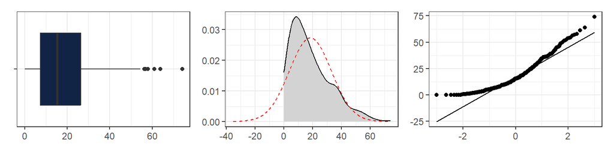

La famille Lachnospiraceae comporte 24 genres différents. Elle est l’une des 14 familles de l’ordre Clostridiales et de la classe Clostridia, et l’une des 26 familles du phylum Firmicutes. La famille Lachnospiraceae est présente chez 99% des enfants. Utiliser en continue ?

## Les genres de la famille Ruminococcaceae

| ch_feces_phylum_ASVbased_Y1 | ch_feces_class_ASVbased_Y1 | ch_feces_order_ASVbased_Y1 | ch_feces_family_ASVbased_Y1 | ch_feces_genus_ASVbased_Y1 |
| --- | --- | --- | --- | --- |
| Firmicutes | Clostridia | Clostridiales | Ruminococcaceae | Faecalibacterium |
| Firmicutes | Clostridia | Clostridiales | Ruminococcaceae | Gemmiger |
| Firmicutes | Clostridia | Clostridiales | Ruminococcaceae | Ruminococcus |
| Firmicutes | Clostridia | Clostridiales | Ruminococcaceae | Flavonifractor |
| Firmicutes | Clostridia | Clostridiales | Ruminococcaceae | Subdoligranulum |
| Firmicutes | Clostridia | Clostridiales | Ruminococcaceae | Oscillibacter |
| Firmicutes | Clostridia | Clostridiales | Ruminococcaceae | Intestinimonas |
| Firmicutes | Clostridia | Clostridiales | Ruminococcaceae | Anaerotruncus |
| Firmicutes | Clostridia | Clostridiales | Ruminococcaceae | Clostridium_IV |
| Firmicutes | Clostridia | Clostridiales | Ruminococcaceae | Pseudoflavonifractor |
| Firmicutes | Clostridia | Clostridiales | Ruminococcaceae | Sporobacter |
| Firmicutes | Clostridia | Clostridiales | Ruminococcaceae | Butyricicoccus |
| Firmicutes | Clostridia | Clostridiales | Ruminococcaceae | Hydrogenoanaerobacterium |
| Firmicutes | Clostridia | Clostridiales | Ruminococcaceae | Acetanaerobacterium |
| Firmicutes | Clostridia | Clostridiales | Ruminococcaceae | Anaerofilum |
| Firmicutes | Clostridia | Clostridiales | Ruminococcaceae | Clostridium_III |
| Firmicutes | Clostridia | Clostridiales | Ruminococcaceae | Cellulosibacter |
| Firmicutes | Clostridia | Clostridiales | Ruminococcaceae | Anaerobacterium |
| Firmicutes | Clostridia | Clostridiales | Ruminococcaceae | Ethanoligenens |

Table 12: Distribution of family Ruminococcaceae (f4)

| **Characteristic** | **Continuous** **N = 356**<sup>1</sup> | **Categorical (Y/N)** **N = 356**<sup>2</sup> |
| --- | --- | --- |
| One year child feces relative abundance of family Ruminococcaceae | 6.67 (1.9, 13.1) |  |
| No |  | 5 (1.4%) |
| Yes |  | 351 (99%) |

<sup>1</sup> Median (IQR)  
<sup>2</sup> n (%)

Figure 2: Distribution of family Ruminococcaceae (f4)

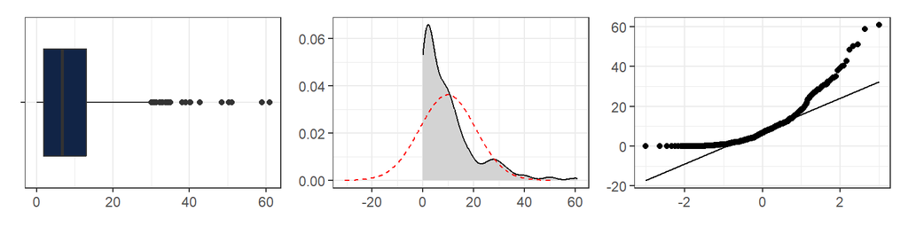

La famille Ruminococcaceae comporte 19 genres différents. Elle est l’une des 14 familles de l’ordre Clostridiales et de la classe Clostridia, et l’une des 26 familles du phylum Firmicutes. La famille Ruminococcaceae est présente chez 99% des enfants. Utiliser en continue ?

# Bactéries identifiées néfastes

Les taxons identifiés comme néfastes pour le neurodéveloppement sont : - espèce Campylobacter jejuni - espèce Clostridium difficile –> la métagénomique 16S ne permet pas de différencier correctement les bactéries au niveau de l’espèce, nous regarderons les genres correspondant de ces espèces.

## Genre Campylabacter

| ch_feces_phylum_ASVbased_Y1 | ch_feces_class_ASVbased_Y1 | ch_feces_order_ASVbased_Y1 | ch_feces_family_ASVbased_Y1 | ch_feces_genus_ASVbased_Y1 |
| --- | --- | --- | --- | --- |
| Proteobacteria | Epsilonproteobacteria | Campylobacterales | Campylobacteraceae | Campylobacter |

Table 13: Distribution of genus Campylobacter (g138)

| **Characteristic** | **Continuous** **N = 356**<sup>1</sup> | **Categorical (Y/N)** **N = 356**<sup>2</sup> |
| --- | --- | --- |
| One year child feces relative abundance of genus Campylobacter | 0.00 (0.0, 0.0) |  |
| No |  | 354 (99%) |
| Yes |  | 2 (0.6%) |

<sup>1</sup> Median (IQR)  
<sup>2</sup> n (%)

Campylobacter est l’unique genre de la famille Campylobacteraceae, de l’ordre Campylobacterales, et de la class Epsilonproteobacteria. Il fait partie du phylum Protéobacteria avec 40 autres genres. Il n’est pas assez détecté dans les selles des enfants pour être considéré dans les analyses (2/356 (0,6%)).

## Genres Clostridium

| ch_feces_phylum_ASVbased_Y1 | ch_feces_class_ASVbased_Y1 | ch_feces_order_ASVbased_Y1 | ch_feces_family_ASVbased_Y1 | ch_feces_genus_ASVbased_Y1 |
| --- | --- | --- | --- | --- |
| Firmicutes | Clostridia | Clostridiales | Clostridiaceae_1 | Clostridium_sensu_stricto |
| Firmicutes | Erysipelotrichia | Erysipelotrichales | Erysipelotrichaceae | Clostridium_XVIII |
| Firmicutes | Clostridia | Clostridiales | Peptostreptococcaceae | Clostridium_XI |
| Firmicutes | Clostridia | Clostridiales | Ruminococcaceae | Clostridium_IV |
| Firmicutes | Clostridia | Clostridiales | Ruminococcaceae | Clostridium_III |

Table 14: Distribution of Clostridium genera

| **Characteristic** | **Continuous** **N = 356**<sup>1</sup> | **Categorical (Y/N)** **N = 356**<sup>2</sup> |
| --- | --- | --- |
| One year child feces relative abundance of genus Clostridium_XlVa | 0.91 (0.3, 2.5) |  |
| No |  | 14 (3.9%) |
| Yes |  | 342 (96%) |
| One year child feces relative abundance of genus Clostridium_XVIII | 0.70 (0.3, 1.8) |  |
| No |  | 5 (1.4%) |
| Yes |  | 351 (99%) |
| One year child feces relative abundance of genus Clostridium_sensu_stricto | 0.16 (0.0, 0.9) |  |
| No |  | 40 (11%) |
| Yes |  | 316 (89%) |
| One year child feces relative abundance of genus Clostridium_IV | 0.07 (0.0, 0.3) |  |
| No |  | 73 (21%) |
| Yes |  | 283 (79%) |
| One year child feces relative abundance of genus Clostridium_XlVb | 0.00 (0.0, 0.0) |  |
| No |  | 281 (79%) |
| Yes |  | 75 (21%) |
| One year child feces relative abundance of genus Clostridium_III | 0.00 (0.0, 0.0) |  |
| No |  | 347 (97%) |
| Yes |  | 9 (2.5%) |
| One year child feces relative abundance of genus Clostridium_XI | 0.00 (0.0, 0.0) |  |
| No |  | 272 (76%) |
| Yes |  | 84 (24%) |

<sup>1</sup> Median (IQR)  
<sup>2</sup> n (%)